# Benefits and Limitations of Ensemble Learning

Zach Quicksall

8/5/2020

## Introduction

Ensembling is an approach to predictive modeling used within the fields of statistics/data science/machine learning to enhance predictive accuracy by combining the strengths (and weaknesses) of multiple models. This improved prediction is the result of combining model types in ways that reduce variance (*bagging*), limit bias (*boosting*), or simply average-out the strengths and weaknesses of the group as a whole (*model stacking*).

With the exception of model stacking, most ensembled models make use of a single type of base learner which are trained in multitude. It is the method of training these base learners that differentiates ensembling approaches as being **linear** or **parallel**.

Linear ensembling methods train models sequentially such that the next model in the sequence is weighted to better-predict the failures of the prior model. This leads to learners that are trained in an increasingly biased manner and makes use of the dependence between the base learners to enhance overall prediction.

Parallel ensembles train base learners independently of each other using appraoches to data sampling which capture different aspects of the data. The learners are then combined to reduce variance. Model stacking is a form of parallel ensembling that combines models of different **types**–rather than the same base learner–to improve performance. Their individual predictions are then aggregated to make a final decision.

## Simulate data

To enhance the illustration of each ensembling approach, we will use a simulated data set which allows us to control the complexity and noise.

```r
# Sizable difference between groups (in continuous features)
dataset_b = data.frame(class = as.factor(rep(classes, length.out = n_each * 3)),
                       f1 = rnorm(n_each * 3, c(0, 3, 6), 3),
                       f2 = rep(c("A","B","C","D", "E"), times = (n_each / 5)),
                       f3 = runif(n_each * 3, c(4,6,8), c(7,9,11)),
                       f4 = rnorm(n_each * 3, c(0, 4, 8), 3) + 3.7)

head(dataset_b) %>%
  kable() %>%
  kable_styling(bootstrap_options = c("striped", "hover", "condensed"), full_width=FALSE)
```

| class | f1 | f2 | f3 | f4 |
| --- | --- | --- | --- | --- |
| 0 | 2.313449 | A | 4.961057 | 2.102664 |
| 1 | 3.852979 | B | 6.946629 | 12.472322 |
| 2 | 9.122747 | C | 9.955615 | 10.019290 |
| 0 | 2.645654 | D | 4.045387 | 4.717625 |
| 1 | 3.708202 | E | 6.329609 | 11.917561 |
| 2 | 7.193559 | A | 9.244199 | 16.161400 |

```r
# Split into training, validation, and testing sets
train_ind = seq(1,dim(dataset_b)[1], 3)
val_ind = train_ind + 1
test_ind = val_ind + 1

# Sort dataframe by class
dataset_b = dataset_b[order(dataset_b$class), ]

# Subset
train_b = dataset_b[train_ind, ]
val_b = dataset_b[val_ind, ]
test_b = dataset_b[-c(train_ind, val_ind), ]
```

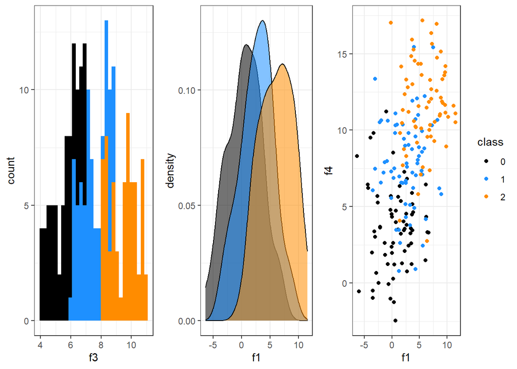

## Individual models

To create a baseline for comparison, we will first train a couple of base learners and evaluate their performance.

### Decision Tree

Decision trees are a supervised learning algorithm which have a flowchart-like structure with each node representing a “test” or “comparison” on the data which separates instances into groups. Upon reaching the bottom of the tree, a final probability is generated to assign instances to their most-likely class.

Decision trees have the benefit of simple visualization and offer the individual an **understanding** of what the algorithm is looking at to make its decision. However, decision trees in isolation have a strong tendency to overfit the training data and exhibit high bias and poor generalization.

Nonetheless, we will use a decision tree as one of our two base models for classification.

```r
# Fit model
dt_mod = train(class ~ .,
               data = train_b,
               method = "rpart")

# Train predictions
dt_train_pred = predict(dt_mod, train_b)

# Test predictions
dt_test_pred = predict(dt_mod, test_b)
```

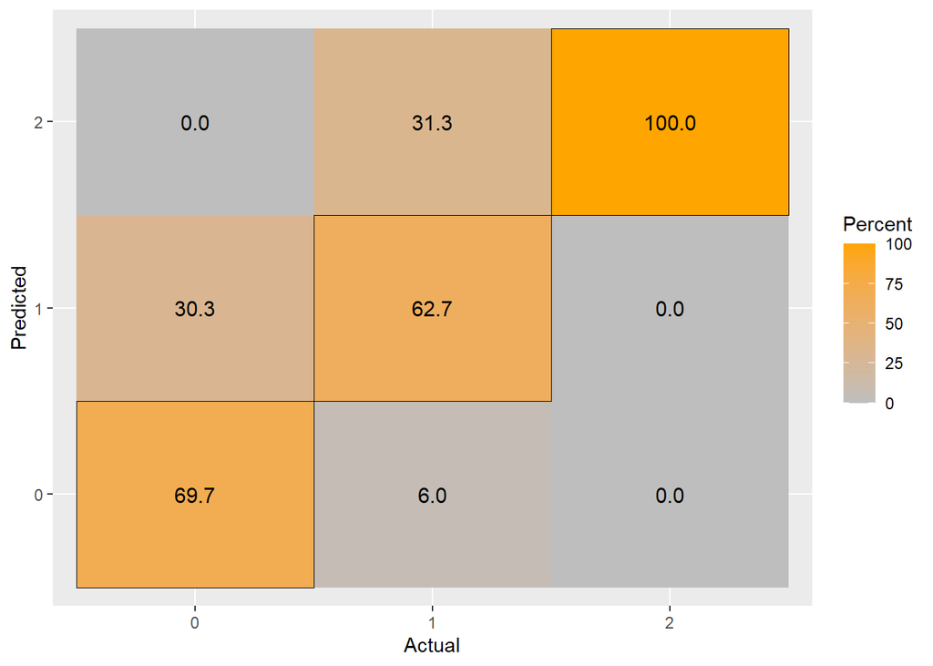

```r
# Define function for visualizing the confusion matrix
view_confusion_matrix = function(actual_values, predicted_values) {

  tmp = data.frame(Actual = actual_values, Predicted = predicted_values)
  actual = as.data.frame(table(tmp$Actual))
  names(actual) = c("Actual", "ActualFreq")
  confusion = as.data.frame(table(tmp$Actual, tmp$Predicted))
  names(confusion) = c("Actual", "Predicted", "Freq")
  confusion = merge(confusion, actual, by = c("Actual"))
  confusion$Percent = confusion$Freq / confusion$ActualFreq * 100

  confusion %>%
    ggplot() +
    geom_tile(aes(x = Actual, y = Predicted, fill = Percent), data = confusion) +
    geom_text(aes(x=Actual,y=Predicted, label=sprintf("%.1f", Percent)), data=confusion, size=4, colour="black") +
    scale_fill_gradient(low="grey",high="orange") +
    geom_tile(aes(x=Actual,y=Predicted),data=subset(confusion, Actual == Predicted), color="black",size=0.3, fill="black", alpha=0)

}
```

### K Nearest neighbors (kNN)

For our other model, we will take a different theoretical approach and use a k-nearest neighbors classifier. This model assigns a class to a particular instance by looking at the classes of the nearest k neighboring instances.

```r
# Knn grid for parameter tuning (in this instance we are not actually tuning, just specifying k)
knn_grid = expand.grid(k = c(5))

# Fit model
knn_mod = train(class ~ .,
                data = train_b,
                method = "knn",
                tuneGrid = knn_grid)

# Train predictions
knn_train_pred = predict(knn_mod, train_b)

# Test predictions
knn_test_pred = predict(knn_mod, test_b)
```

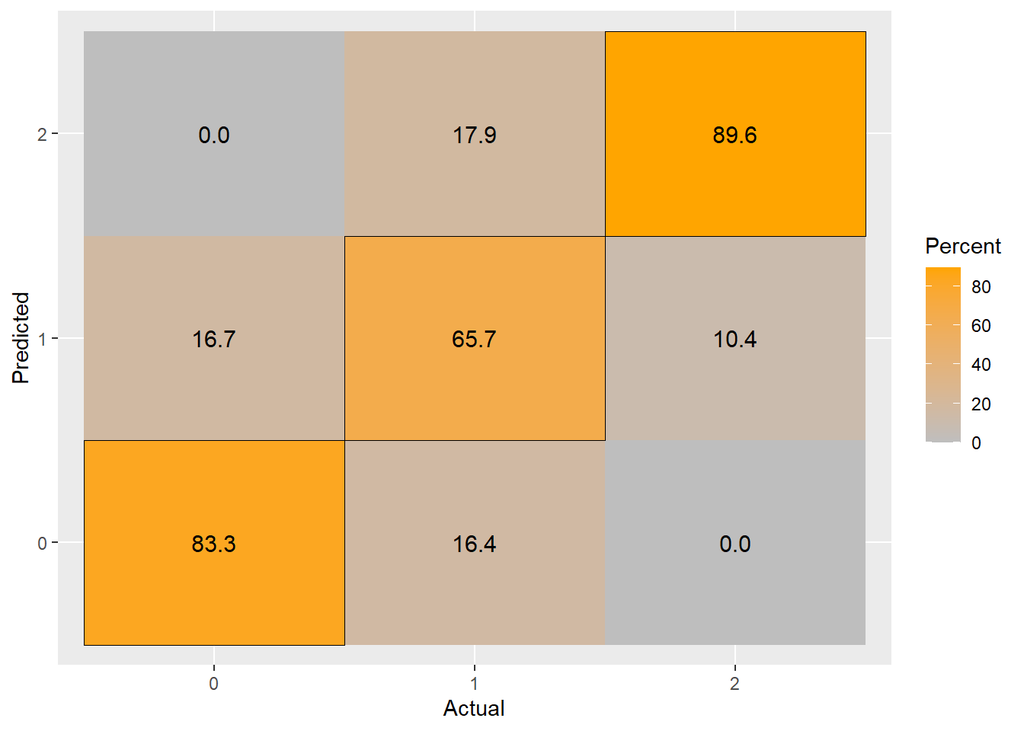

How might we be able to improve the classification of class 1 without substantially affecting our high accuracy on the other two classes? For the remainder of this document, we will explore three techniques for utilizing the bias/variance trade-off and improve overall classification.

## Bagging (i.e. bootstrap-aggregating)

Bagging is a **parallel** ensembling approach which creates many models independently such that they independently capture the variance in the data. In aggregate, this variance is reduced by the natural overlap of the models which leads to more accurate prediction.

Bagging can be applied to almost any base learner, but is often seen used in the context of decision trees to create an ensembling model more commonly known as a *random forest*.

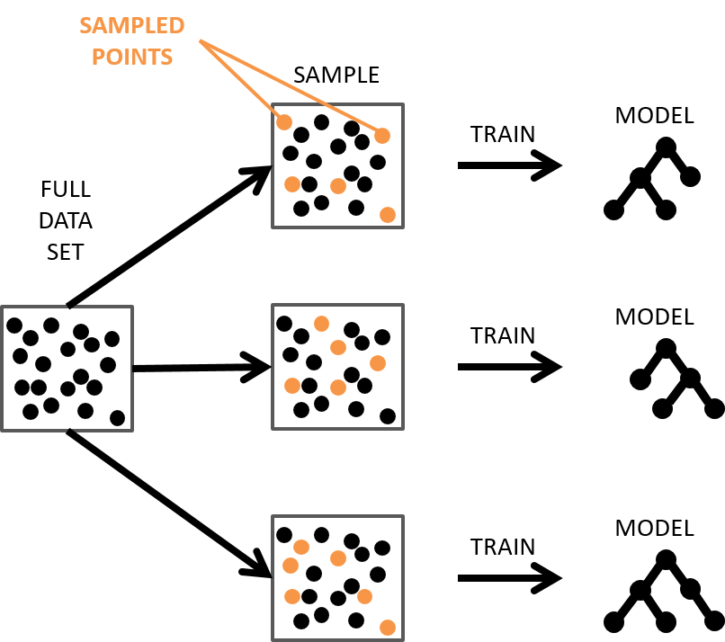

Bagging

The above diagram illustrates the construction of the random forest. Subsets of our training data set (orange circles) are randomly sampled and used to construct a decision tree. These samples are then replaced and the process is repeated many times (typically 500 - 1000) to create a **forest** of decision trees. The individual predictions are then aggregated to generate a final class prediction.

```r
# Fit model
rf_mod = train(class ~ .,
               data = train_b,
               method = "rf")

# Train predictions
rf_train_pred = predict(rf_mod, train_b)

# Test predictions
rf_test_pred = predict(rf_mod, test_b)
```

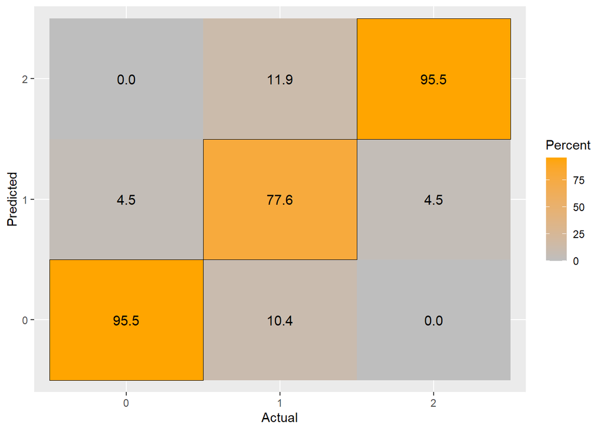

## Boosting

Boosting is a **sequential** ensembling approach which incrementally constructs base learners which are trained on the residual data from the prior learning model. This process generates models in a linear fashion such that the next model is more accurate at predicting the failures of the previous model. The complexity of these base learners is kept minimal to limit variance while accepting greater bias. In aggregate, the overall bias is reduced to enhance predictive accuracy.

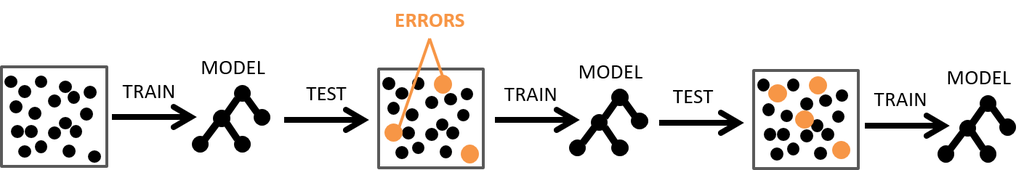

Boosting

The above diagram of boosting may be somewhat less intuitive than that for random forests. As mentioned, boosted tree models are constructed in series by re-weighting examples (the larger orange circles) that the prior models failed to properly classify. As such, this sequence of models becomes better-tuned to the unique instances in the data.

```r
# Fit model
gbm_mod = train(class ~ .,
                data = train_b,
                method = "gbm",
                verbose = FALSE)

# Train predictions
gbm_train_pred = predict(gbm_mod, train_b)

# Test predictions
gbm_test_pred = predict(gbm_mod, test_b)
```

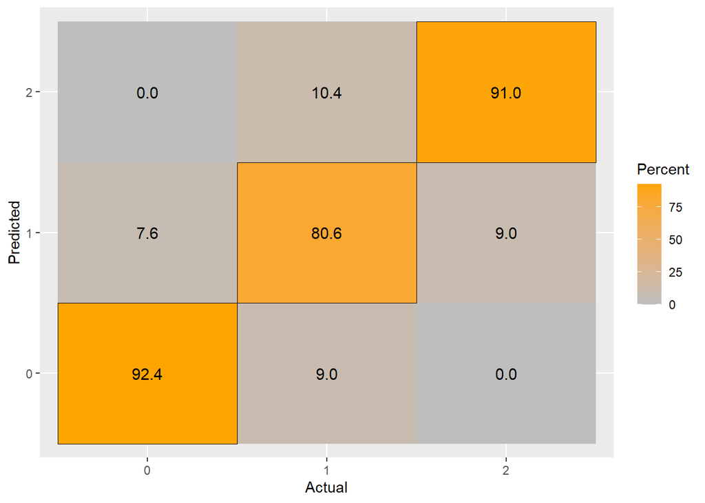

## Stacking

Model stacking has been shown to be a powerful tool in many machine learning competitions. The theory behind model stacking is that a collection of classifiers that have different strengths and weaknesses can be combined to provide more accurate predictions than any of the models in isolation. The key difference between stacking and the prior ensembling approaches is that stacking is specifically designed to combine the predictions of **different** model types (e.g. decision trees **and** kNN classifiers).

There are two forms of stacking that are used in practice (cross-validation and holdout). The differences between the two will not be discussed in detail here, but we will illustrate the benefits of stacking in general by using the holdout approach since it is simpler overall and easier to visualize.

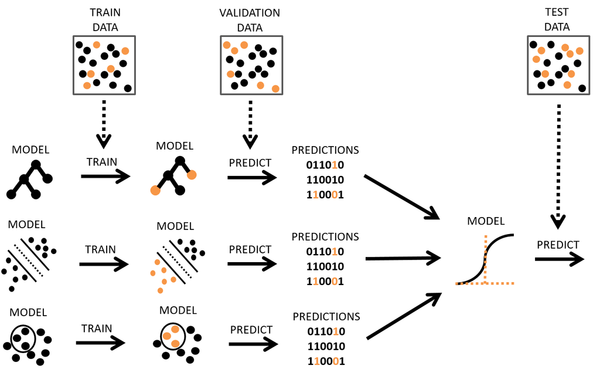

Stacking

In the diagram above we can see that we have split our data set into three different groups (training, validation, and testing as represented by the orange circles). These data sets are independent of each other and contain no overlapping samples (unlike those of the bagging/boosting approaches).

First, the training data set is used to train a variety of predictive models (models shown include decision trees, kNN, and support vector machines). Next, these models are used to predict the classes of instances in the *validation* data set. These predictions are then provided as “features” to a final model (most often a logistic/linear regression) which is trained to predict their “true” class. A final testing data set is used to evaluate the fully stacked ensemble.

In our example below, we will train a variety of classifiers:

- k-nearest neighbor
- Random forest
- Gradient boosting machine
- Linear discriminant analysis
- Naive bayes classifier

And stack them using a multinomial logistic regression model.

It is important to note that model stacking works **best** when the predictions from the various base models are uncorrelated. This allows the combined models to benefit each other by overcoming the weaknesses of the individual models.

In this simulated data, however, we see that the individual predictions are highly correlated. and are perhaps the **least** correlated when predicting class 1. This is promising given that we had the greatest trouble early on in predicting this class.

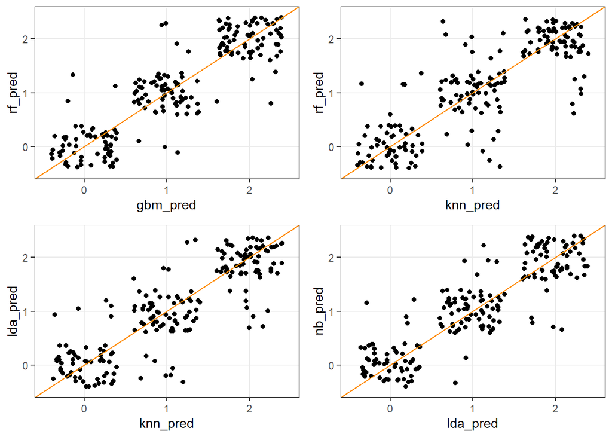

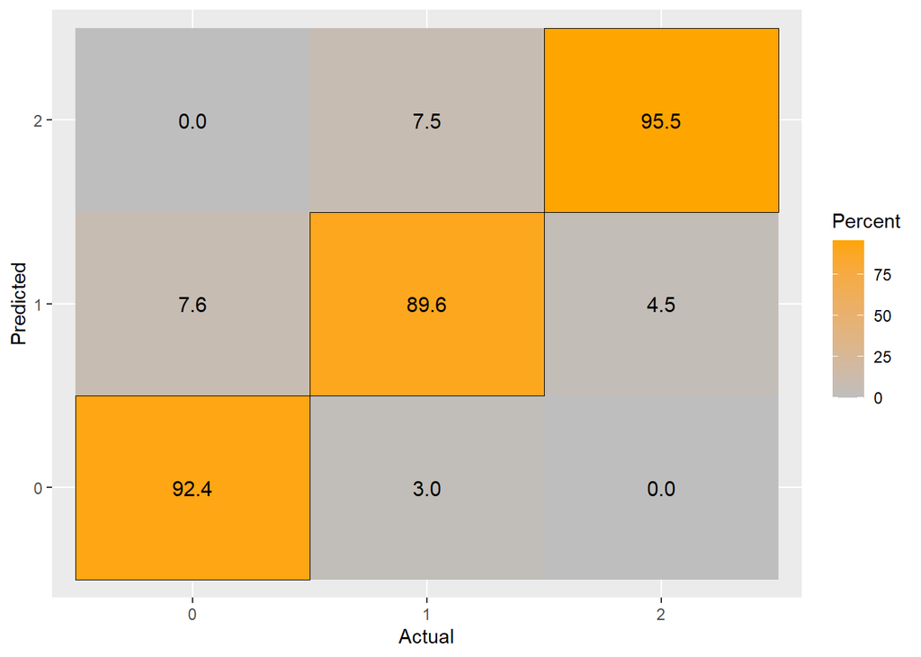

This document has conveyed the basic principles of ensembling and highlighted some of the benefits and weaknesses. I encourage you to explore ensembling in your own modeling problems utilizing a greater variety of models than shown here.